# Specifying our Structural Causal Model

```r
library(tidyverse)
clean_data <- read.csv("data/clean_state_data.csv")
clean_data$phf_per_capita[is.na(clean_data$phf_per_capita) & clean_data$state == "Georgia"] <- 108
clean_data$phf_per_capita[is.na(clean_data$phf_per_capita) & clean_data$state == "Mississippi"] <- 567831325/2954160
```

## Endogenous Variables

### Exposure:

$A$, whether or not a state has state-level permissive vaccine exemptions. Specifically, states allowing all personal, religious, and medical exemptions (coded as 1) compared to states allowing only religious exemptions or only medical exemptions (coded as 0).

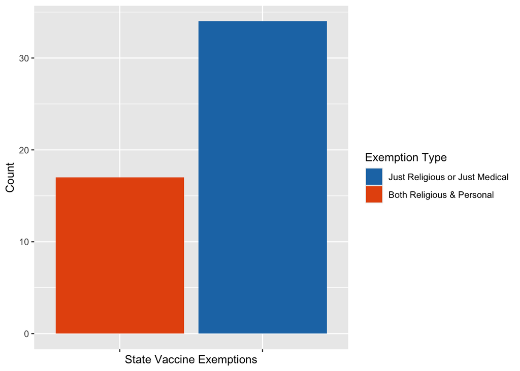

```r
clean_data %>%
  mutate(exemp_pol = case_when(
    exposure_binary == 1 ~ "Both Religious & Personal",
    exposure_binary == 0 ~ "Religious or Medical"
  )) %>%
  ggplot(aes(x=exemp_pol, fill = as.factor(exposure_binary))) +
  geom_bar() +
  xlab("State Vaccine Exemptions") +
  ylab("Count") +
  scale_fill_manual(
    name = "Exemption Type",   # legend title
    values = c("0" = "#1f77b4", "1" = "#e6550d"),  # your colors
    labels = c("0" = "Just Religious or Just Medical",
               "1" = "Both Religious & Personal")
  ) +
 theme(axis.text.x = element_blank())
```

### Outcome:

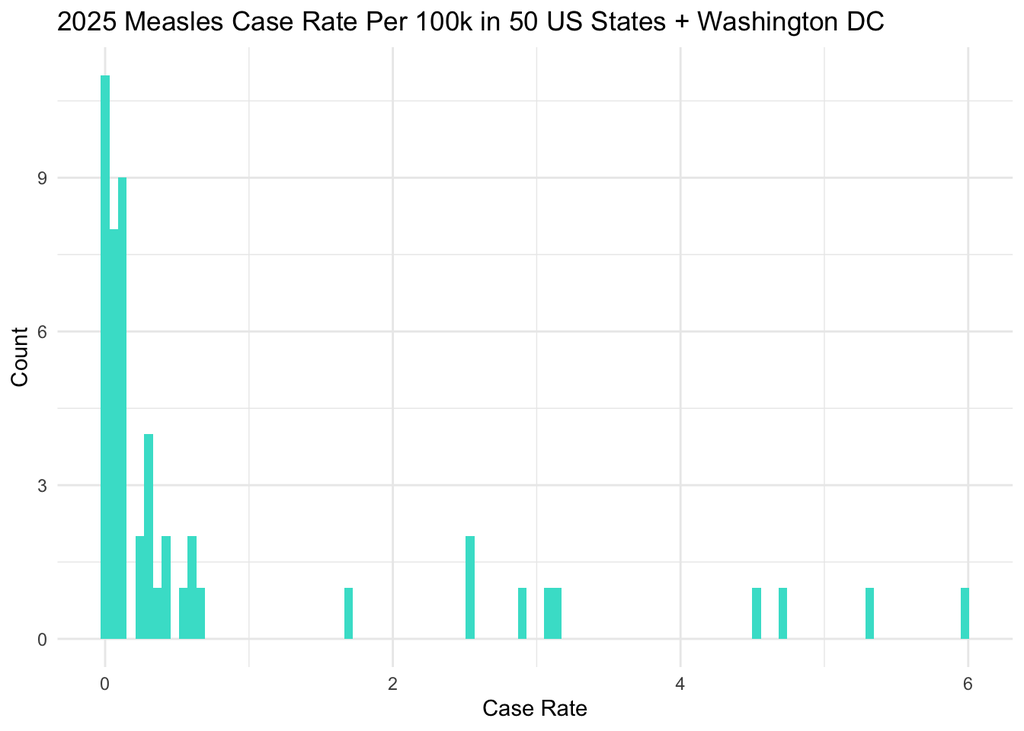

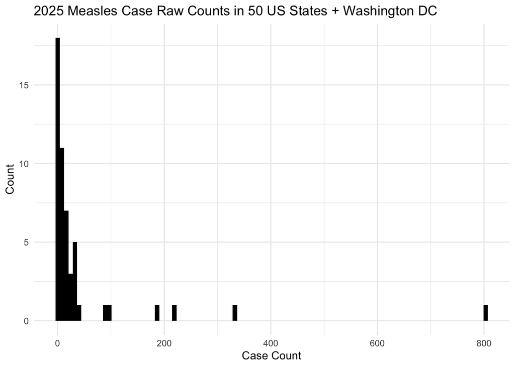

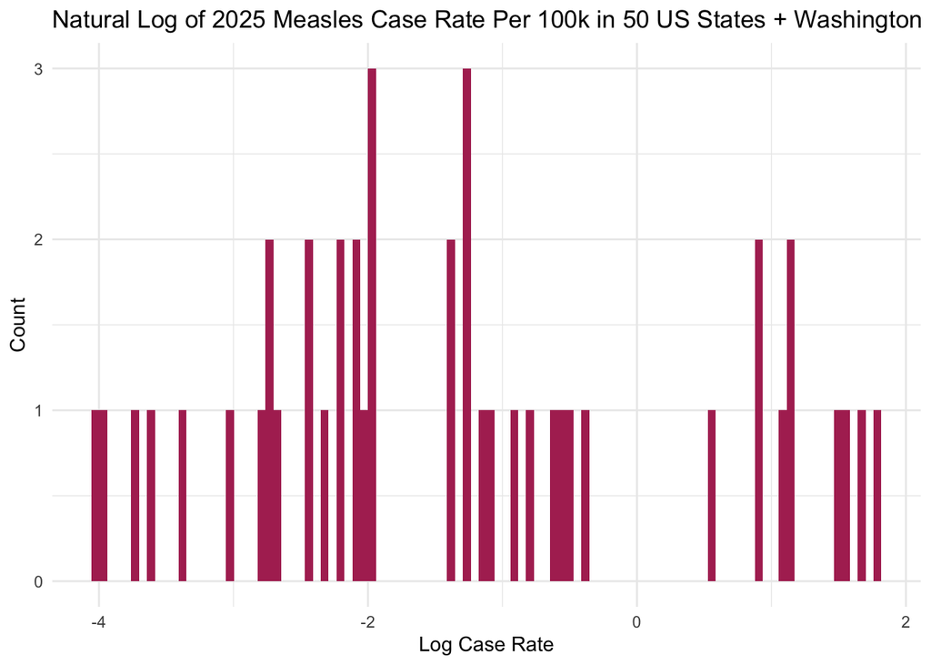

Although our outcome is right-skewed, we will use continuous counts/rates, since dichotomizing the outcome will lead to a loss of variability and power in our statistical estimations. Additionally, there is not clear cut-off that makes sense for these data.

### Confounders:

Classified as $W$ in our DAG, these include statewide attributes:

1. % of individuals with any health insurance covery (continuous)
2. % of individuals aged 25+ with Bachelor’s degrees or higher (continuous)
3. % of individuals who lived in an “urban” area as classified by census data (continuous)
4. % of people living below the poverty line (continuous)
5. Median household income (continuous)
6. Public health funding per capita (continuous)

Univariate analyses of our confounders are shown below:

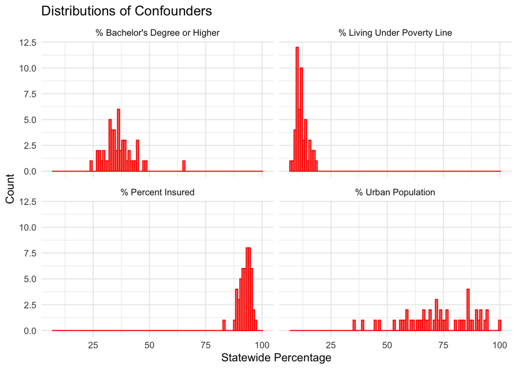

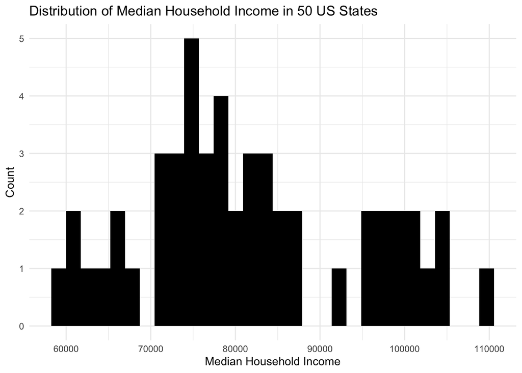

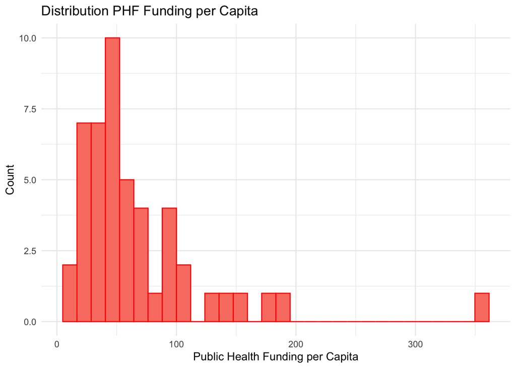

### Mediators (assumed to occur in between exposure and outcome, on the causal pathway):

One potential mediator, $M$, we identified was statewide measles vaccine coverage. We did not include this data in our model since we do not want to adjust for variables on the causal pathway.

## Full Structural Equation Model

$$X = \{W,A, Y\}$$

- $W =$ State Level Confounders
- $A =$ Exposure (Statewide Permissive Vaccine Exmptions)
- $Y =$ Outcome (Statewide Measles Case Rate per 100k)

$$U = \{U_W,U_A, U_Y\}$$
- Since our exposure was not randomized, we cannot assume that any of our background factors are independent from one another.

### Structural Equations

$$W = f_W(U_W)$$
$$A = f_A(W, U_A)$$
$$Y = f_Y(W, A, U_Y)$$

## Target Causal Parameter

Our target causal parameter is the average treatment effect (ATE) of permissive vaccine exemption policies on 2025 measles case rates across U.S. states.

Based on our model above, we let $A$ denote the exposure, where $A = 1$ corresponds to states with permissive exemption policies (both personal and religious exemptions allowed), and $A = 0$ corresponds to states with more restrictive exemption policies (religious-only or medical-only exemptions). $Y$ denotes the outcome, defined as the 2025 measles case rate per 100k population at the state level (and is continuous).

The target causal estimand is the average treatment effect:

$$\text{ATE} = \mathbb{E}[Y(1) - Y(0)] = \mathbb{E}[Y \mid (A=1)] -
\mathbb{E}[Y \mid(A=0)]$$

where $Y(1)$ and $Y(0)$ represent the potential outcomes under permissive and restrictive exemption policies, respectively.

### Identification Assumptions

To identify this causal effect from observational data, we that our potential outcomes are independent from our exposure, conditioned on $W$ (exchangeability),

$$Y(1), Y(0) \perp A \mid W$$

where $W$ is the set of observed confounders listed above. Our model assumes that, conditional on $W$, there are no unmeasured common causes of vaccine exemption policy and measles incidence.

Under these assumptions, our causal effect is identifiable.